[figure not shown]

# EDA • Exᴘʟᴏʀᴀᴛᴏʀʏ Dᴀᴛᴀ Aɴᴀʟʏsɪs

## ISIS SANTOS COSTA • 2021

## Exᴘʟᴏʀᴀᴛᴏʀʏ Dᴀᴛᴀ Aɴᴀʟʏsɪs • Resuming: retrieving the DF, final transformed

```python
import pandas as pd
```

```python
import warnings
warnings.filterwarnings('ignore')
```

```python
#!pip install ipython-autotime
%load_ext autotime
```

```
time: 0 ns
```

```python
pd.set_option('display.max_columns', None)
```

```
time: 32 ms
```

### Data by order

```python
with open('df_orders_tF.csv') as f: cols = f.readline().split(',')
del cols[0]
cols[-1] = cols[-1].replace('\n','')
df = pd.read_csv('df_orders_tF.csv', usecols=cols) # reading previously transformed data
df.head(2)
```

|  | order_id | passenger_id | pickup_datetime | pickup_month | pickup_week | pickup_weekinmonth | pickup_date | pickup_dayofweek | pickup_isweekend | pickup_hour | pickup_isrush | pickup_latitude | pickup_longitude | dropoff_latitude | dropoff_longitude | dropoff_datetime | duration | duration_minutes | duration_type | trip_distance | total_amount | fare_amount | tip_amount | rate_type | payment_type | pickup_borough | dropoff_borough |
| --- | --- | --- | --- | --- | --- | --- | --- | --- | --- | --- | --- | --- | --- | --- | --- | --- | --- | --- | --- | --- | --- | --- | --- | --- | --- | --- | --- |
| 0 | 6433697 | 5234567816269547 | 2014-04-11 18:06:45 | 4 | 15 | 2 | 2014-04-11 | Friday | 0 | 18 | 1 | 40.714476 | -74.015684 | 40.718173 | -74.000814 | 2014-04-11 18:18:19 | 0 days 00:11:34 | 11.566667 | 10-20min | 1.6 | 13.2 | 9.5 | 2.2 | Standard | CRD | Manhattan • Lower Manhattan | Manhattan • Lower Manhattan |
| 1 | 6433698 | 5234567812367422 | 2014-04-12 00:20:28 | 4 | 15 | 2 | 2014-04-12 | Saturday | 1 | 0 | 0 | 40.713247 | -73.958403 | 40.758526 | -73.991395 | 2014-04-12 00:47:19 | 0 days 00:26:51 | 26.850000 | 20-30min | 5.5 | 27.0 | 22.0 | 4.0 | Standard | CRD | Brooklyn | Manhattan • Midtown Manhattan |

```
time: 3min 6s
```

```python
# bckp, in case there is any issue with our df being improved
with open('df_orders_tF.csv') as f: cols = f.readline().split(',')
del cols[0]
cols[-1] = cols[-1].replace('\n','')
df_original = pd.read_csv('df_orders_tF.csv', usecols=cols) # reading previously transformed data
```

```
time: 7min 18s
```

```python
print(df.columns == df_original.columns)
```

```
[ True  True  True  True  True  True  True  True  True  True  True  True
  True  True  True  True  True  True  True  True  True  True  True  True
  True  True  True]
time: 375 ms
```

### Daily data

```python
df_daily = pd.read_csv('df_orders_tF_daily.csv') # reading previously transformed data
df_daily.head(2)
```

|  | pickup_date | total_orders | total_trips | pickup_month | pickup_week | pickup_weekinmonth | pickup_dayofweek | pickup_isweekend | pickup_hour | pickup_isrush | pickup_latitude | pickup_longitude | dropoff_latitude | dropoff_longitude | duration_minutes | duration_type | trip_distance | total_amount | fare_amount | tip_amount | Standard | JFK | Newark | Nassau / Westchester | Negotiated | Group ride | CRD | CSH | UNK | … |
| --- | --- | --- | --- | --- | --- | --- | --- | --- | --- | --- | --- | --- | --- | --- | --- | --- | --- | --- | --- | --- | --- | --- | --- | --- | --- | --- | --- | --- | --- | --- |
| 0 | 2014-03-01 | 277284 | 211545 | 3 | 9 | 1 | Saturday | 1 | 13.127753 | 0.425838 | 40.084363 | -72.772283 | 40.060088 | -72.725061 | 12.191076 | 10-20min | 2.766199 | 14.058896 | 11.856336 | 1.333832 | 208065 | 2672 | 229 | 39 | 540 | 0 | 155788 | 119182 | 1414 | … |
| 1 | 2014-03-02 | 231264 | 176557 | 3 | 9 | 1 | Sunday | 1 | 11.634141 | 0.409126 | 40.099519 | -72.797495 | 40.053491 | -72.709109 | 11.277417 | 10-20min | 3.103580 | 14.641738 | 12.269199 | 1.421354 | 172260 | 3455 | 295 | 54 | 486 | 7 | 132324 | 97072 | 1100 | … |

```
time: 406 ms
```

### Data by passenger

```python
df_passenger = pd.read_csv('df_orders_tF_passenger.csv') # reading previously transformed data
df_passenger.head(2)
```

|  | passenger_id | total_orders | pickup_month | pickup_week | pickup_weekinmonth | pickup_isweekend | pickup_hour | pickup_isrush | pickup_latitude | pickup_longitude | dropoff_latitude | dropoff_longitude | duration_minutes | trip_distance | total_amount | fare_amount | tip_amount |
| --- | --- | --- | --- | --- | --- | --- | --- | --- | --- | --- | --- | --- | --- | --- | --- | --- | --- |
| 0 | 5234567812345678 | 160 | 3.693750 | 14.468750 | 2.718750 | 0.250000 | 13.493750 | 0.481250 | 40.242022 | -73.052296 | 40.404677 | -73.347880 | 12.556356 | 2.509576 | 13.457712 | 11.368644 | 1.065169 |
| 1 | 5234567812345679 | 132 | 3.689394 | 14.484848 | 2.727273 | 0.295455 | 14.469697 | 0.469697 | 40.443271 | -73.415126 | 40.355975 | -73.257267 | 13.465372 | 3.031456 | 16.101359 | 13.218447 | 1.701845 |

```
time: 33 s
```

## Exᴘʟᴏʀᴀᴛᴏʀʏ Dᴀᴛᴀ Aɴᴀʟʏsɪs • Organizing features into classes

👀 *Let's take a look at the features again to choose the relations to be visually inspected.*

### Features List • Data by order

```python
list(df.columns)
```

```
['order_id',
 'passenger_id',
 'pickup_datetime',
 'pickup_month',
 'pickup_week',
 'pickup_weekinmonth',
 'pickup_date',
 'pickup_dayofweek',
 'pickup_isweekend',
 'pickup_hour',
 'pickup_isrush',
 'pickup_latitude',
 'pickup_longitude',
 'dropoff_latitude',
 'dropoff_longitude',
 'dropoff_datetime',
 'duration',
 'duration_minutes',
 'duration_type',
 'trip_distance',
 'total_amount',
 'fare_amount',
 'tip_amount',
 'rate_type',
 'payment_type',
 'pickup_borough',
 'dropoff_borough']
```

```
time: 79 ms
```

### Features List • Daily data

```python
list(df_daily.columns)
```

```
['pickup_date',
 'total_orders',
 'total_trips',
 'pickup_month',
 'pickup_week',
 'pickup_weekinmonth',
 'pickup_dayofweek',
 'pickup_isweekend',
 'pickup_hour',
 'pickup_isrush',
 'pickup_latitude',
 'pickup_longitude',
 'dropoff_latitude',
 'dropoff_longitude',
 'duration_minutes',
 'duration_type',
 'trip_distance',
 'total_amount',
 'fare_amount',
 'tip_amount',
 'Standard',
 'JFK',
 'Newark',
 'Nassau / Westchester',
 'Negotiated',
 'Group ride',
 'CRD',
 'CSH',
 'UNK',
 'NOC',
 'DIS',
 'pickup ‖ Manhattan • Lower Manhattan',
 'pickup ‖ Manhattan • Midtown Manhattan',
 'pickup ‖ Manhattan • Upper Manhattan',
 'pickup ‖ Queens',
 'pickup ‖ Brooklyn',
 'pickup ‖ Manhattan • Harlem',
 'pickup ‖ Manhattan • Washington Heights',
 'pickup ‖ Bronx',
 'pickup ‖ Staten Island',
 'dropoff ‖ Manhattan • Lower Manhattan',
 'dropoff ‖ Manhattan • Midtown Manhattan',
 'dropoff ‖ Manhattan • Upper Manhattan',
 'dropoff ‖ Queens',
 'dropoff ‖ Brooklyn',
 'dropoff ‖ Manhattan • Harlem',
 'dropoff ‖ Manhattan • Washington Heights',
 'dropoff ‖ Bronx',
 'dropoff ‖ Staten Island']
```

```
time: 15 ms
```

### Features List • Data by passenger

```python
list(df_passenger.columns)
```

```
['passenger_id',
 'total_orders',
 'pickup_month',
 'pickup_week',
 'pickup_weekinmonth',
 'pickup_isweekend',
 'pickup_hour',
 'pickup_isrush',
 'pickup_latitude',
 'pickup_longitude',
 'dropoff_latitude',
 'dropoff_longitude',
 'duration_minutes',
 'trip_distance',
 'total_amount',
 'fare_amount',
 'tip_amount']
```

```
time: 16 ms
```

### Features classes • All orders

| Iɴᴘᴜᴛ |  |  |  |  |  | Tᴀʀɢᴇᴛ |
| --- | --- | --- | --- | --- | --- | --- |
| Cʟɪᴇɴᴛ ᴀᴄᴄᴏᴜɴᴛ | Tɪᴍᴇ | Dᴜʀᴀᴛɪᴏɴ | Dɪsᴛᴀɴᴄᴇ | Lᴏᴄᴀᴛɪᴏɴ | Pᴀʏᴍᴇɴᴛ ᴛʏᴘᴇ | Hᴀᴘᴘɪɴᴇss & Rᴇᴠᴇɴᴜᴇ |
| **passenger_id*** | **pickup_isweekend** | **duration_type** | **trip_distance** | **pickup_borough** | **payment_type** | **tip_amount (Hᴀᴘᴘɪɴᴇss)** |
|  | **pickup_isrush** | **duration_minutes** |  | **dropoff_borough** |  | **total_amount (Rᴇᴠᴇɴᴜᴇ)** |
|  | **pickup_month** | duration |  | **rate_type**** |  | fare_amount (Rᴇᴠᴇɴᴜᴇ) |
|  | **pickup_weekinmonth** |  |  |  |  |  |
|  | **pickup_dayofweek** |  |  |  |  |  |
|  | **pickup_hour** |  |  |  |  |  |
|  | pickup_datetime |  |  |  |  |  |
|  | pickup_week |  |  |  |  |  |
|  | pickup_date |  |  |  |  |  |
|  | dropoff_datetime |  |  |  |  |  |

* **bold features are representative of the whole class**  
** *rate_type* classified considering it is mostly location-related, only exception being the 'group' ride

### Features classes • Daily data

| Iɴᴘᴜᴛ |  |  |  |  |  | Tᴀʀɢᴇᴛ |
| --- | --- | --- | --- | --- | --- | --- |
| Cʟɪᴇɴᴛ ᴛʀᴀɴsᴀᴄᴛɪᴏɴs | Tɪᴍᴇ | Dᴜʀᴀᴛɪᴏɴ | Dɪsᴛᴀɴᴄᴇ | Lᴏᴄᴀᴛɪᴏɴ | Pᴀʏᴍᴇɴᴛ ᴛʏᴘᴇ | Hᴀᴘᴘɪɴᴇss & Rᴇᴠᴇɴᴜᴇ |
| **total_orders*** | **pickup_date** | **duration_type** | **trip_distance** | **pickup_borough** (specified) | **payment_type** (specified) | **tip_amount (Hᴀᴘᴘɪɴᴇss)** |
| **total_trips** | **pickup_isweekend** | **duration_minutes** |  | **dropoff_borough** (specified) |  | **total_amount (Rᴇᴠᴇɴᴜᴇ)** |
|  | **pickup_isrush** |  |  | **rate_type**** (specified) |  | fare_amount (Rᴇᴠᴇɴᴜᴇ) |
|  | **pickup_month** |  |  | pickup_latitude |  |  |
|  | **pickup_weekinmonth** |  |  | pickup_longitude |  |  |
|  | **pickup_dayofweek** |  |  | dropoff_latitude |  |  |
|  | **pickup_hour** |  |  | dropoff_longitude |  |  |
|  | pickup_datetime |  |  |  |  |  |
|  | pickup_week |  |  |  |  |  |
|  | dropoff_datetime |  |  |  |  |  |

* **bold features are representative of the whole class**  
** *rate_type* classified considering it is mostly location-related, only exception being the 'group' ride

### Features classes • Data by passenger

| Iɴᴘᴜᴛ |  |  |  |  | Tᴀʀɢᴇᴛ |
| --- | --- | --- | --- | --- | --- |
| Cʟɪᴇɴᴛ ᴛʀᴀɴsᴀᴄᴛɪᴏɴs | Tɪᴍᴇ | Dᴜʀᴀᴛɪᴏɴ | Dɪsᴛᴀɴᴄᴇ | Lᴏᴄᴀᴛɪᴏɴ | Hᴀᴘᴘɪɴᴇss & Rᴇᴠᴇɴᴜᴇ |
| **total_orders*** | **pickup_isweekend** | **duration_type** | **trip_distance** | **pickup_latitude** | **tip_amount (Hᴀᴘᴘɪɴᴇss)** |
|  | **pickup_isrush** | **duration_minutes** |  | **pickup_longitude** | **total_amount (Rᴇᴠᴇɴᴜᴇ)** |
|  | **pickup_month** |  |  | **dropoff_latitude** | fare_amount (Rᴇᴠᴇɴᴜᴇ) |
|  | **pickup_weekinmonth** |  |  | **dropoff_longitude** |  |
|  | **pickup_hour** |  |  |  |  |
|  | **pickup_week** |  |  |  |  |

* **bold features are representative of the whole class**

## Exᴘʟᴏʀᴀᴛᴏʀʏ Dᴀᴛᴀ Aɴᴀʟʏsɪs • Importing matplotlib

```python
%matplotlib inline

import matplotlib as mpl
import matplotlib.pyplot as plt

mpl.style.use('ggplot')
```

```
time: 6.16 s
```

## Exᴘʟᴏʀᴀᴛᴏʀʏ Dᴀᴛᴀ Aɴᴀʟʏsɪs • Raw data (by order) ‖ Correlations

🔎 *By searching for correlations, we can understand pairwise interactions between variables and also check for possible reductions towards **data efficiency**.*

### Predictor x Predictor: Trip duration *vs.* distance

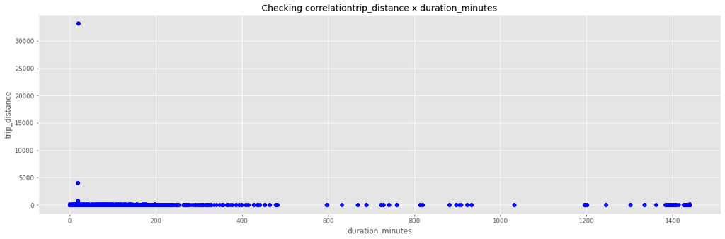

```
time: 26.6 s
```

```python
# Checking correlation trip duration x distance
x, y = df['duration_minutes'], df['trip_distance']

plt.figure(figsize=(20, 6))
plt.scatter(x, y, c='blue')
plt.title('Checking correlation'+ y.name + ' x '+ x.name)
plt.xlabel(x.name)
plt.ylabel(y.name)
plt.show()
```

*Those two points below 30 minutes, close to 4,000 miles and 34,000 miles, respectively, correspond to around **8k miles/hour** and **~70k miles/hour**.*

*Even for some extravagant scientific experiment of maybe Tesla visionaires this seem a little too much: safe to drop.* 🧹

```python
indexNames = df[ (df['trip_distance'] > 2000) ].index
df.drop(indexNames, inplace=True)
max(df['trip_distance'])
```

```
800.5
```

```
time: 9min 34s
```

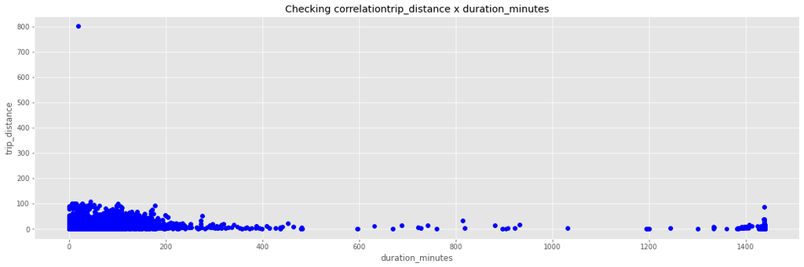

```
time: 1min 3s
```

```python
# Checking correlation trip duration x distance
x, y = df['duration_minutes'], df['trip_distance']

plt.figure(figsize=(20, 6))
plt.scatter(x, y, c='blue')
plt.title('Checking correlation'+ y.name + ' x '+ x.name)
plt.xlabel(x.name)
plt.ylabel(y.name)
plt.show()
```

🧹 *1,600 miles/hour still not credible: let's drop further.*

```python
indexNames = df[ (df['trip_distance'] > 800) ].index
df.drop(indexNames, inplace=True)
max(df['trip_distance'])
```

```
108.9
```

```
time: 12min 45s
```

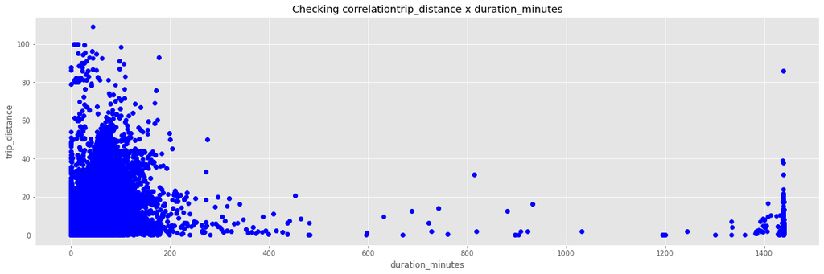

```
time: 35.1 s
```

```python
# Checking correlation trip duration x distance
x, y = df['duration_minutes'], df['trip_distance']

plt.figure(figsize=(20, 6))
plt.scatter(x, y, c='blue')
plt.title('Checking correlation'+ y.name + ' x '+ x.name)
plt.xlabel(x.name)
plt.ylabel(y.name)
plt.show()
```

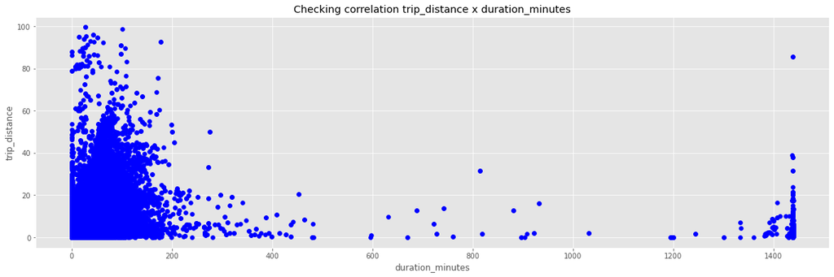

```
time: 1min 12s
```

```python
# Checking correlation trip duration x distance: filtered by distance < threshold
threshold = 100
x, y = df.loc[df['trip_distance'] < threshold, 'duration_minutes'], df.loc[df['trip_distance'] < threshold, 'trip_distance']

plt.figure(figsize=(20, 6))
plt.scatter(x, y, c='blue')
plt.title('Checking correlation '+ y.name + ' x '+ x.name)
plt.xlabel(x.name)
plt.ylabel(y.name)
plt.show()
```

### Predictor x Predictor: Dropoff latitude *vs.* Pickup latitude

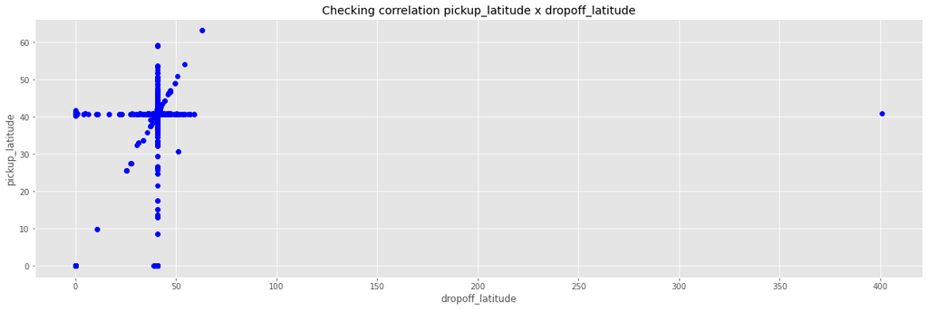

```
time: 27.4 s
```

```python
# Checking correlation Dropoff latitude x Pickup latitude
x, y = df['dropoff_latitude'], df['pickup_latitude']

plt.figure(figsize=(20, 6))
plt.scatter(x, y, c='blue')
plt.title('Checking correlation '+ y.name + ' x '+ x.name)
plt.xlabel(x.name)
plt.ylabel(y.name)
plt.show()
```

🤔 *Linear interactions display a curious pattern.*  
🛠️ *The point showing around 400 for dropoff latitude value is wrong, let's fix 'dropoff_latitude' to the valid range: -90° to 90°.*

```python
df['dropoff_latitude'].describe()
```

```
count    1.145622e+07
mean     3.997215e+01
std      5.581361e+00
min      0.000000e+00
25%      4.073346e+01
50%      4.075306e+01
75%      4.076830e+01
max      4.009167e+02
Name: dropoff_latitude, dtype: float64
```

```
time: 1.23 s
```

```python
df['dropoff_latitude'] = df.loc[df['dropoff_latitude'] <= 90, 'dropoff_latitude']
df['dropoff_latitude'].describe()
```

```
count    1.145622e+07
mean     3.997212e+01
std      5.580342e+00
min      0.000000e+00
25%      4.073346e+01
50%      4.075306e+01
75%      4.076830e+01
max      6.312818e+01
Name: dropoff_latitude, dtype: float64
```

```
time: 11.6 s
```

```python
df.count()
```

```
order_id              14999994
passenger_id          14999994
pickup_datetime       14999994
pickup_month          14999994
pickup_week           14999994
pickup_weekinmonth    14999994
pickup_date           14999994
pickup_dayofweek      14999994
pickup_isweekend      14999994
pickup_hour           14999994
pickup_isrush         14999994
pickup_latitude       14999994
pickup_longitude      14999994
dropoff_latitude      11456220
dropoff_longitude     11456221
dropoff_datetime      11456221
duration              11456221
duration_minutes      11456221
duration_type         11456221
trip_distance         11456221
total_amount          11456221
fare_amount           11456221
tip_amount            11456221
rate_type             11456221
payment_type          14999994
pickup_borough        14999994
dropoff_borough       11456221
dtype: int64
```

```
time: 10.3 s
```

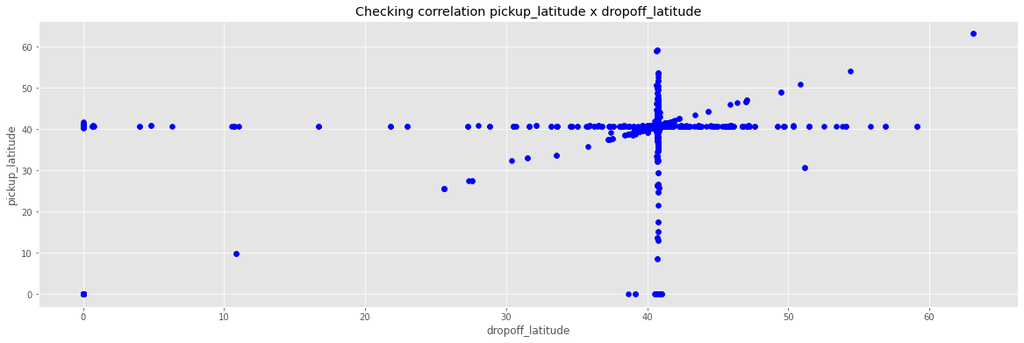

```
time: 35.5 s
```

```python
# Checking correlation Dropoff latitude x Pickup latitude
x, y = df['dropoff_latitude'], df['pickup_latitude']

plt.figure(figsize=(20, 6))
plt.scatter(x, y, c='blue')
plt.title('Checking correlation '+ y.name + ' x '+ x.name)
plt.xlabel(x.name)
plt.ylabel(y.name)
plt.show()
```

🛠️ Although any point in the range -90° to 90° would be valid, many of the points are not credible, **reaching outside the US and even crossing waters**.  
So, let's further **clean data to keep latitudes within the '48 contiguous states continuously above water'**.  
By this criterion,  
the southernmost point is **[24.520833](https://en.wikipedia.org/wiki/List_of_extreme_points_of_the_United_States)**.  
</i> the northernmost point is **[49.384472](https://en.wikipedia.org/wiki/List_of_extreme_points_of_the_United_States)**.  
(Degrees Decimal Minutes (DDM) converted to Decimal Degrees (DD) [here](https://www.pgc.umn.edu/apps/convert/)).

```python
df['pickup_latitude'] = df.loc[(df['pickup_latitude'] >= 24.520833) & (df['pickup_latitude'] <= 49.384472), 'pickup_latitude']
df['pickup_latitude'].describe()
```

```
count    1.472689e+07
mean     4.075073e+01
std      3.724275e-02
min      2.479546e+01
25%      4.073633e+01
50%      4.075327e+01
75%      4.076738e+01
max      4.891002e+01
Name: pickup_latitude, dtype: float64
```

```
time: 4.62 s
```

```python
df['dropoff_latitude'] = df.loc[(df['dropoff_latitude'] >= 24.520833) & (df['dropoff_latitude'] <= 49.384472), 'dropoff_latitude']
df['dropoff_latitude'].describe()
```

```
count    1.123719e+07
mean     4.075110e+01
std      3.957435e-02
min      2.557423e+01
25%      4.073494e+01
50%      4.075377e+01
75%      4.076858e+01
max      4.922112e+01
Name: dropoff_latitude, dtype: float64
```

```
time: 3.47 s
```

```python
df.count()
```

```
order_id              14999994
passenger_id          14999994
pickup_datetime       14999994
pickup_month          14999994
pickup_week           14999994
pickup_weekinmonth    14999994
pickup_date           14999994
pickup_dayofweek      14999994
pickup_isweekend      14999994
pickup_hour           14999994
pickup_isrush         14999994
pickup_latitude       14726894
pickup_longitude      14999994
dropoff_latitude      11237187
dropoff_longitude     11456221
dropoff_datetime      11456221
duration              11456221
duration_minutes      11456221
duration_type         11456221
trip_distance         11456221
total_amount          11456221
fare_amount           11456221
tip_amount            11456221
rate_type             11456221
payment_type          14999994
pickup_borough        14999994
dropoff_borough       11456221
dtype: int64
```

```
time: 8.59 s
```

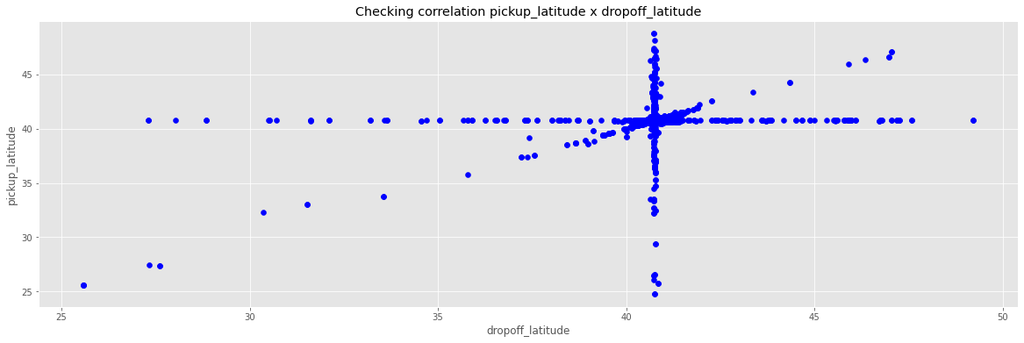

```
time: 33.6 s
```

```python
# Checking correlation Dropoff latitude x Pickup latitude
x, y = df['dropoff_latitude'], df['pickup_latitude']

plt.figure(figsize=(20, 6))
plt.scatter(x, y, c='blue')
plt.title('Checking correlation '+ y.name + ' x '+ x.name)
plt.xlabel(x.name)
plt.ylabel(y.name)
plt.show()
```

*Nice.* 🙂

### Predictor x Predictor: Dropoff longitude *vs.* Pickup longitude

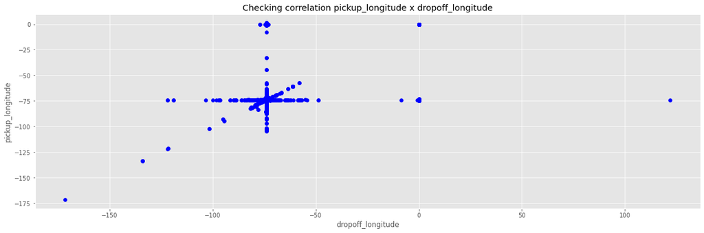

```
time: 26.5 s
```

```python
# Checking correlation Dropoff longitude x Pickup longitude
x, y = df['dropoff_longitude'], df['pickup_longitude']

plt.figure(figsize=(20, 6))
plt.scatter(x, y, c='blue')
plt.title('Checking correlation '+ y.name + ' x '+ x.name)
plt.xlabel(x.name)
plt.ylabel(y.name)
plt.show()
```

*Same as for latitudes, as expected.* 🤔

🛠️ The easternmost dropoff longitude at +120° (positive!) would be a destination in China.  
It would possibly be -120°, but - **as we have plenty of data** - let's simply drop it</b>.

🛠️ *As for latitudes, although any point in the range -180° to 180° would be valid, let's **clean data to keep longitudes within a credible range**:*  
Easternmost point on the U.S. mainland: **[-66.949778](https://en.wikipedia.org/wiki/List_of_extreme_points_of_the_United_States)**.  
</i> Westernmost point on the U.S. mainland (contiguous): **[-124.733056](https://en.wikipedia.org/wiki/List_of_extreme_points_of_the_United_States)**.  
(Degrees Decimal Minutes (DDM) converted to Decimal Degrees (DD) [here](https://www.pgc.umn.edu/apps/convert/)).

```python
df['pickup_longitude'].describe()
```

```
count    1.500000e+07
mean    -7.262919e+01
std      9.889962e+00
min     -1.714464e+02
25%     -7.399212e+01
50%     -7.398188e+01
75%     -7.396731e+01
max      1.213851e+00
Name: pickup_longitude, dtype: float64
```

```
time: 2.42 s
```

```python
df['pickup_longitude'] = df.loc[(df['pickup_longitude'] >= -124.733056) & (df['pickup_longitude'] <= -66.949778), 'pickup_longitude']
df['pickup_longitude'].describe()
```

```
count    1.472689e+07
mean    -7.397584e+01
std      5.922525e-02
min     -1.219261e+02
25%     -7.399232e+01
50%     -7.398213e+01
75%     -7.396841e+01
max     -6.713012e+01
Name: pickup_longitude, dtype: float64
```

```
time: 4.06 s
```

```python
df['dropoff_longitude'].describe()
```

```
count    1.145623e+07
mean    -7.256022e+01
std      1.012975e+01
min     -1.714464e+02
25%     -7.399138e+01
50%     -7.397991e+01
75%     -7.396281e+01
max      1.218270e+02
Name: dropoff_longitude, dtype: float64
```

```
time: 921 ms
```

```python
df['dropoff_longitude'] = df.loc[(df['dropoff_longitude'] >= -124.733056) & (df['dropoff_longitude'] <= -66.949778), 'dropoff_longitude']
df['dropoff_longitude'].describe()
```

```
count    1.123718e+07
mean    -7.397429e+01
std      6.203673e-02
min     -1.219261e+02
25%     -7.399156e+01
50%     -7.398036e+01
75%     -7.396428e+01
max     -6.743661e+01
Name: dropoff_longitude, dtype: float64
```

```
time: 3.42 s
```

```python
df.count()
```

```
order_id              14999994
passenger_id          14999994
pickup_datetime       14999994
pickup_month          14999994
pickup_week           14999994
pickup_weekinmonth    14999994
pickup_date           14999994
pickup_dayofweek      14999994
pickup_isweekend      14999994
pickup_hour           14999994
pickup_isrush         14999994
pickup_latitude       14726894
pickup_longitude      14726888
dropoff_latitude      11237187
dropoff_longitude     11237178
dropoff_datetime      11456221
duration              11456221
duration_minutes      11456221
duration_type         11456221
trip_distance         11456221
total_amount          11456221
fare_amount           11456221
tip_amount            11456221
rate_type             11456221
payment_type          14999994
pickup_borough        14999994
dropoff_borough       11456221
dtype: int64
```

```
time: 9.2 s
```

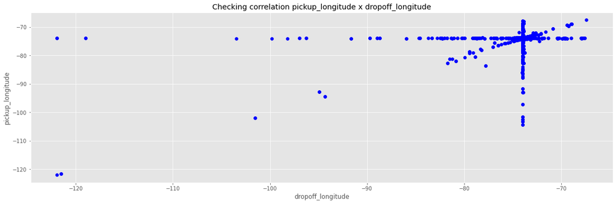

```
time: 26.4 s
```

```python
# Checking correlation Dropoff longitude x Pickup longitude
x, y = df['dropoff_longitude'], df['pickup_longitude']

plt.figure(figsize=(20, 6))
plt.scatter(x, y, c='blue')
plt.title('Checking correlation '+ y.name + ' x '+ x.name)
plt.xlabel(x.name)
plt.ylabel(y.name)
plt.show()
```

*Now we see a feasible geographic coverage.* 🙂

### Predictor x Predictor: Dropoff datetime *vs.* Pickup datetime

*When setting variables for feature engineering, we previously decided that - in terms of time - **just** looking at the **pickup** part would be **enough**.*

Now let's have an idea ( 👀 *) of what is being left out:*

```python
df['dropoff_datetime'] = pd.to_datetime(df['dropoff_datetime'])
df['dropoff_datetime'].head(3)
```

```
0   2014-04-11 18:18:19
1   2014-04-12 00:47:19
2   2014-04-11 23:59:41
Name: dropoff_datetime, dtype: datetime64[ns]
```

```
time: 14 s
```

```python
df['pickup_datetime'] = pd.to_datetime(df['pickup_datetime'])
df['pickup_datetime'].head(3)
```

```
0   2014-04-11 18:06:45
1   2014-04-12 00:20:28
2   2014-04-11 23:51:28
Name: pickup_datetime, dtype: datetime64[ns]
```

```
time: 15.6 s
```

```python
print(df['dropoff_datetime'].dtype)
print(df['pickup_datetime'].dtype)
```

```
datetime64[ns]
datetime64[ns]
time: 687 ms
```

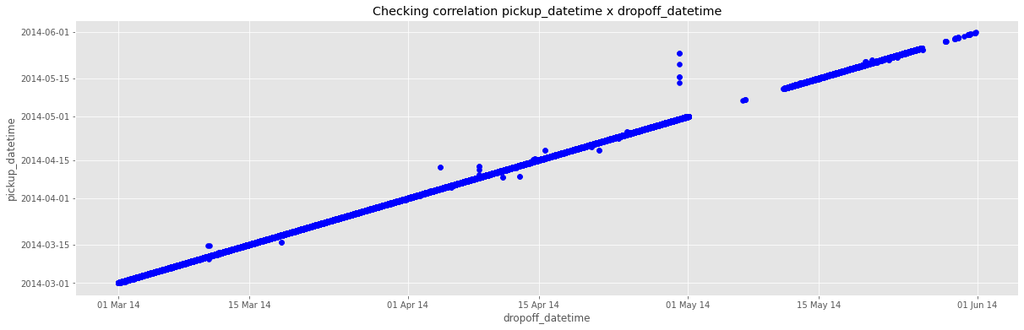

```
time: 28.9 s
```

```python
# Checking correlation Dropoff datetime x Pickup datetime
x, y = df['dropoff_datetime'], df['pickup_datetime']

plt.figure(figsize=(20, 6))
plt.scatter(x, y, c='blue')
plt.title('Checking correlation '+ y.name + ' x '+ x.name)
plt.xlabel(x.name)
plt.ylabel(y.name)

import matplotlib.dates as mdates
dtFmt = mdates.DateFormatter('%d %b %y')
plt.gca().xaxis.set_major_formatter(dtFmt)

plt.show()
```

💡 **Strongly linearly correlated, so taking only the pickup_datetime (with derivates) into account seems pretty fine.**

Note: we observe a long period without any trip, them 'a pair of rebels'(?) in what could be interpreted as a brief quarantine for today standards. Yet, there was a concern about Ebola in 2014. For the purpose of integrating present as part of a long-time study, just normalizing *the data would be fine.*

### Predictor x Predictor: Speed *vs.* Pickup hour

💨 *Typical speeds impact planning operations, so let's add a new feature,* 'avg_mph'*, a check its correlation to the hour of the day.*

```python
df['mph'] = df['trip_distance'] / df['duration_minutes'] * 60
```

```
time: 7.95 s
```

```python
df['mph'].head()
```

```
0     8.299712
1    12.290503
2    11.683570
3     7.986348
4    10.037679
Name: mph, dtype: float64
```

```
time: 47 ms
```

```python
df['mph'].describe()
```

```
count    1.143461e+07
mean              inf
std               NaN
min      0.000000e+00
25%      8.325000e+00
50%      1.129707e+01
75%      1.530000e+01
max               inf
Name: mph, dtype: float64
```

```
time: 1.83 s
```

🛠️ *Void trips, indicating a **duration of 0**, are causing erroneous mph values. Let's **fix** them.*

```python
df.loc[df['duration_minutes'] == 0, 'mph'] = 0
```

```
time: 22.1 s
```

```python
df['mph'].head()
```

```
0     8.299712
1    12.290503
2    11.683570
3     7.986348
4    10.037679
Name: mph, dtype: float64
```

```
time: 5.52 s
```

```python
df['mph'].describe()
```

```
count    1.145622e+07
mean     1.367559e+01
std      1.304318e+02
min      0.000000e+00
25%      8.300000e+00
50%      1.127610e+01
75%      1.526250e+01
max      1.263600e+05
Name: mph, dtype: float64
```

```
time: 5.56 s
```

*Much better.* 🙂  
🛠️ *But still, there are **unrealistic mph values** in our dataset:*

Let's **drop** them. The **high limit speed** will be 45% of that of the 2010 record breaking Bugatti Veyron 16.4 Super Sport*: 45% of [**267.856 mph**](https://en.m.wikipedia.org/wiki/Production_car_speed_record)*

```python
df['mph'] = df.loc[(df['mph'] != 0) & (df['mph'] <= (0.45 * 267.856)), 'mph']
df['mph'].describe()
```

```
count    1.138125e+07
mean     1.269757e+01
std      6.549215e+00
min      1.007078e-02
25%      8.357143e+00
50%      1.130890e+01
75%      1.530000e+01
max      1.200000e+02
Name: mph, dtype: float64
```

```
time: 6.03 s
```

*Great! The case for lowest mph should still be further checked, the highest value is now an excutable one.* 🙂

```python
df.count()
```

```
order_id              14999994
passenger_id          14999994
pickup_datetime       14999994
pickup_month          14999994
pickup_week           14999994
pickup_weekinmonth    14999994
pickup_date           14999994
pickup_dayofweek      14999994
pickup_isweekend      14999994
pickup_hour           14999994
pickup_isrush         14999994
pickup_latitude       14726894
pickup_longitude      14726888
dropoff_latitude      11237187
dropoff_longitude     11237178
dropoff_datetime      11456221
duration              11456221
duration_minutes      11456221
duration_type         11456221
trip_distance         11456221
total_amount          11456221
fare_amount           11456221
tip_amount            11456221
rate_type             11456221
payment_type          14999994
pickup_borough        14999994
dropoff_borough       11456221
mph                   11381250
dtype: int64
```

```
time: 13.1 s
```

```python
df_avg_mph = df[['pickup_hour','mph']].groupby(['pickup_hour']).mean()
df_avg_mph
```

| pickup_hour | mph |
| --- | --- |
| 0 | 15.580295 |
| 1 | 16.114417 |
| 2 | 16.617019 |
| 3 | 17.227740 |
| 4 | 19.455687 |
| 5 | 21.532642 |
| 6 | 17.747107 |
| 7 | 13.774582 |
| 8 | 11.319771 |
| 9 | 10.978287 |
| 10 | 11.170708 |
| 11 | 10.920116 |
| 12 | 10.760997 |
| 13 | 10.950791 |
| 14 | 10.816172 |
| 15 | 10.732087 |
| 16 | 11.428234 |
| 17 | 11.194912 |
| 18 | 11.111478 |
| 19 | 11.891611 |
| 20 | 12.947226 |
| 21 | 13.780544 |
| 22 | 14.108880 |
| 23 | 14.753499 |

```
time: 4.69 s
```

```python
df_avg_mph.index
```

```
Int64Index([ 0,  1,  2,  3,  4,  5,  6,  7,  8,  9, 10, 11, 12, 13, 14, 15, 16,
            17, 18, 19, 20, 21, 22, 23],
           dtype='int64', name='pickup_hour')
```

```
time: 329 ms
```

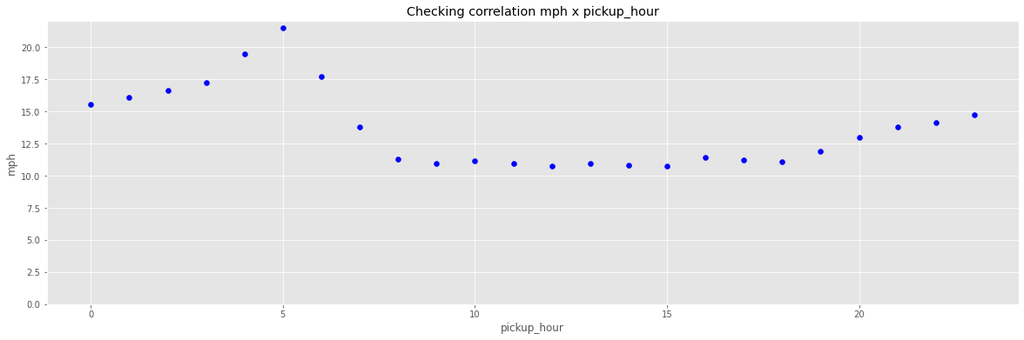

```
time: 20.3 s
```

```python
# Checking correlation Avg(Speed) x Hour

df_avg_mph = df[['pickup_hour','mph']].groupby(['pickup_hour']).mean()

x, y = df_avg_mph.index, df_avg_mph['mph']

plt.figure(figsize=(20, 6))
plt.scatter(x, y, c='blue')
plt.title('Checking correlation '+ y.name + ' x '+ x.name)
plt.xlabel(x.name)
plt.ylabel(y.name)
plt.ylim(ymin=0)

plt.show()
```

### Target x Predictor: tip_amount (Hᴀᴘᴘɪɴᴇss) *vs.* Pickup datetime

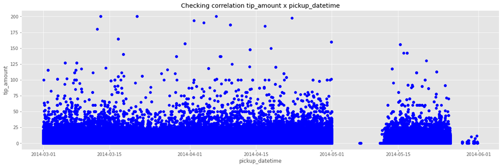

```
time: 30.2 s
```

```python
# Checking correlation Happiness x Pickup datetime
x, y = df['pickup_datetime'], df['tip_amount']

plt.figure(figsize=(20, 6))
plt.scatter(x, y, c='blue')
plt.title('Checking correlation '+ y.name + ' x '+ x.name)
plt.xlabel(x.name)
plt.ylabel(y.name)
plt.show()
```

### Target x Predictor: total_amount (Rᴇᴠᴇɴᴜᴇ) *vs.* Pickup datetime

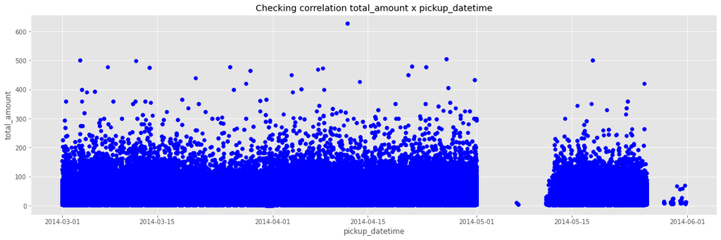

```
time: 28 s
```

```python
# Checking correlation Dropoff longitude x Pickup longitude
x, y = df['pickup_datetime'], df['total_amount']

plt.figure(figsize=(20, 6))
plt.scatter(x, y, c='blue')
plt.title('Checking correlation '+ y.name + ' x '+ x.name)
plt.xlabel(x.name)
plt.ylabel(y.name)
plt.show()
```

### Target x Predictor: tip_amount (Hᴀᴘᴘɪɴᴇss) *vs.* Trip duration

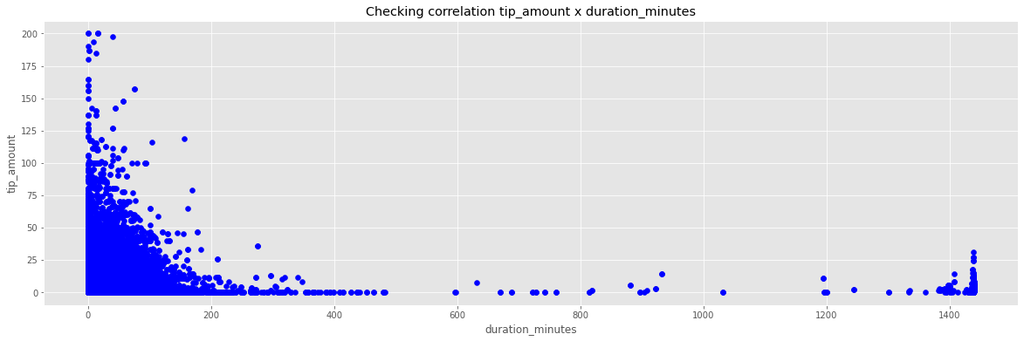

```
time: 25.7 s
```

```python
# Checking correlation Happiness x Trip duration
x, y = df['duration_minutes'], df['tip_amount']

plt.figure(figsize=(20, 6))
plt.scatter(x, y, c='blue')
plt.title('Checking correlation '+ y.name + ' x '+ x.name)
plt.xlabel(x.name)
plt.ylabel(y.name)
plt.show()
```

### Target x Predictor: total_amount (Rᴇᴠᴇɴᴜᴇ) *vs.* Trip duration

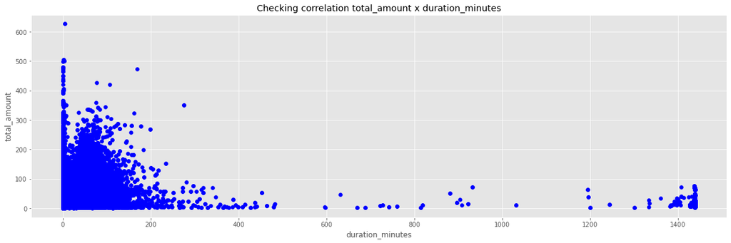

```
time: 25.7 s
```

```python
# Checking correlation Dropoff longitude x Trip duration
x, y = df['duration_minutes'], df['total_amount']

plt.figure(figsize=(20, 6))
plt.scatter(x, y, c='blue')
plt.title('Checking correlation '+ y.name + ' x '+ x.name)
plt.xlabel(x.name)
plt.ylabel(y.name)
plt.show()
```

🤔 **Now things got really strange: are the totals getting lower for higher duration? Weird. Let's take a look at trip distances.**

### Target x Predictor: tip_amount (Hᴀᴘᴘɪɴᴇss) *vs.* Trip length

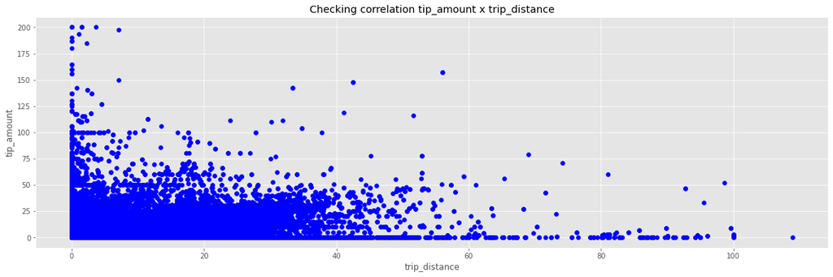

```
time: 25.9 s
```

```python
# Checking correlation Happiness x Trip length
x, y = df['trip_distance'], df['tip_amount']

plt.figure(figsize=(20, 6))
plt.scatter(x, y, c='blue')
plt.title('Checking correlation '+ y.name + ' x '+ x.name)
plt.xlabel(x.name)
plt.ylabel(y.name)
plt.show()
```

```python
df[df['tip_amount'] > 125 ]
```

[output not shown]

```
time: 1.38 s
```

```python
print('Weird ultra-short trips with ultra-high tips:')
print('# trips: '     ,     (df.loc[df['tip_amount'] > 125, 'duration_minutes']).count())
print('avg duration: ', int(round(df.loc[df['tip_amount'] > 125, 'duration_minutes'].mean(),0)))
print('avg distance: ', int(round(df.loc[df['tip_amount'] > 125, 'trip_distance'].mean(),0)))
print('avg tip: '     , int(round(df.loc[df['tip_amount'] > 125, 'tip_amount'].mean(),0)))
```

```
Weird ultra-short trips with ultra-high tips:
# trips:  38
avg duration:  16
avg distance:  8
avg tip:  160
time: 312 ms
```

```python
print('Weird ultra-high tips for zero time:')
print('# trips: '     ,     (df.loc[(df['tip_amount'] > 125) & (df['duration_minutes'] == 0), 'duration_minutes'].count()))
print('avg duration: ', int(round(df.loc[(df['tip_amount'] > 125) & (df['duration_minutes'] == 0), 'duration_minutes'].mean(),0)))
print('avg distance: ', int(round(df.loc[(df['tip_amount'] > 125) & (df['duration_minutes'] == 0), 'trip_distance'].mean(),0)))
print('avg tip: '     , int(round(df.loc[(df['tip_amount'] > 125) & (df['duration_minutes'] == 0), 'tip_amount'].mean(),0)))
```

```
Weird ultra-high tips for zero time:
# trips:  10
avg duration:  0
avg distance:  0
avg tip:  156
time: 547 ms
```

### Target x Predictor: total_amount (Rᴇᴠᴇɴᴜᴇ) *vs.* Trip length

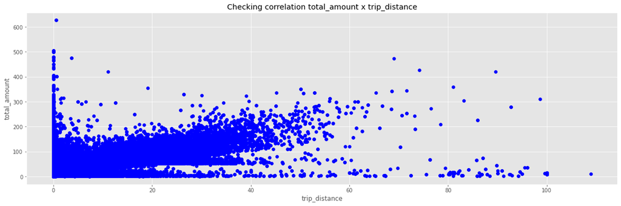

```
time: 26.1 s
```

```python
# Checking correlation Dropoff longitude x Trip length
x, y = df['trip_distance'], df['total_amount']

plt.figure(figsize=(20, 6))
plt.scatter(x, y, c='blue')
plt.title('Checking correlation '+ y.name + ' x '+ x.name)
plt.xlabel(x.name)
plt.ylabel(y.name)
plt.show()
```

```python
threshold = 300
print('Weird ultra-short trips with ultra-high total amount:')
print('# trips: '     ,          (df.loc[df['total_amount'] > threshold, 'duration_minutes']).count())
print('avg duration: ', int(round(df.loc[df['total_amount'] > threshold, 'duration_minutes'].mean(),0)))
print('avg distance: ', int(round(df.loc[df['total_amount'] > threshold, 'trip_distance'].mean(),0)))
print('avg total: '   , int(round(df.loc[df['total_amount'] > threshold, 'total_amount'].mean(),0)))
```

```
Weird ultra-short trips with ultra-high total amount:
# trips:  133
avg duration:  20
avg distance:  12
avg total:  372
time: 125 ms
```

```python
threshold = 300
print('Weird ultra-high tips for zero time:')
print('# trips: '     ,          (df.loc[(df['total_amount'] > threshold) & (df['duration_minutes'] == 0), 'duration_minutes'].count()))
print('avg duration: ', int(round(df.loc[(df['total_amount'] > threshold) & (df['duration_minutes'] == 0), 'duration_minutes'].mean(),0)))
print('avg distance: ', int(round(df.loc[(df['total_amount'] > threshold) & (df['duration_minutes'] == 0), 'trip_distance'].mean(),0)))
print('avg tip: '     , int(round(df.loc[(df['total_amount'] > threshold) & (df['duration_minutes'] == 0), 'total_amount'].mean(),0)))
```

```
Weird ultra-high tips for zero time:
# trips:  56
avg duration:  0
avg distance:  0
avg tip:  382
time: 531 ms
```

🤔 **Now things got really strange: are the totals getting lower with time? Weird. Let's take a look at trip distances.**

## Exᴘʟᴏʀᴀᴛᴏʀʏ Dᴀᴛᴀ Aɴᴀʟʏsɪs • Aggregations: frequency distributions

### Tʀɪᴘs: Frequency distribution by month (%)

```python
orders_by_month = 100 * df['pickup_month'].value_counts() / len(df)
orders_by_month
```

```
4    48.729219
3    40.914683
5    10.356097
Name: pickup_month, dtype: float64
```

```
time: 468 ms
```

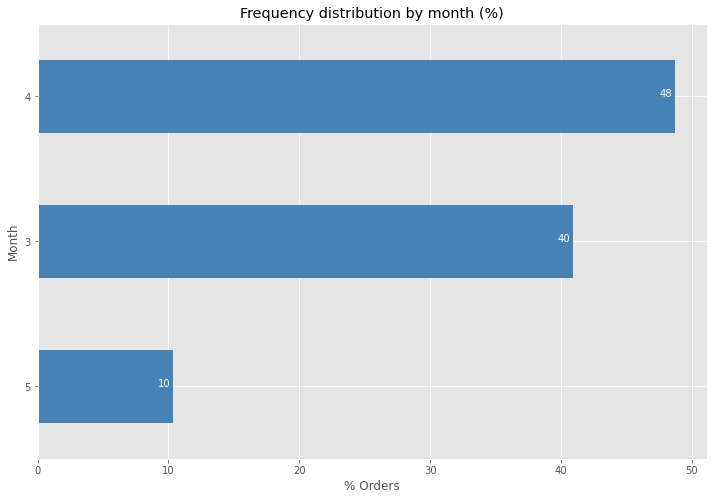

```
time: 2.02 s
```

```python
## Distribution %

orders_by_month.sort_values(ascending=True, inplace=True)
orders_by_month.plot(kind='barh', figsize=(12, 8), color='steelblue')
plt.xlabel('% Orders')
plt.ylabel('Month')
plt.title('Frequency distribution by month (%)')

for i, value in enumerate(orders_by_month):
    label = format(int(value), ',') # format int with commas

    # place text at the end of bar (subtracting 3% from x, and 0 from y to make it fit within the bar)
    plt.annotate(label, xy=(value - 1.2, i - 0), color='white')

plt.show()
```

⚠️ *There seems to be something wrong with data for May, or there was an extreme event hindering taxi-hailing in the period. **Qualitative input needed here.** As mentioned above (Predictor x Predictor: Dropoff datetime vs. Pickup datetime), there were quarantines given to Ebola in 2014 (but, in a quick assess, they seem to have occured later). To be checked.*

### Tʀɪᴘs: Frequency distribution by week of the month (%) [normalized]

```
 Average days in week 5: 2.512708
```

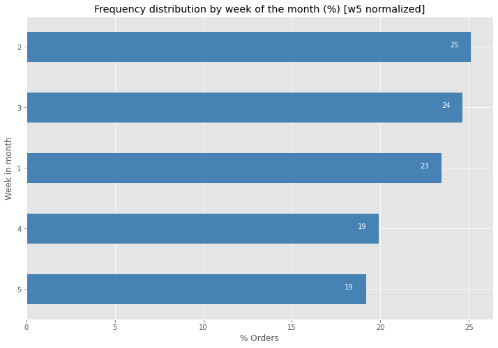

```
time: 1.91 s
```

```python
## Distribution %

days_w5 = 3 * (0.40914707 + 0.10356093) + 2 * (0.48729200) # as seen in 99__DataTransformation3.ipynb
print(' Average days in week 5:', days_w5, '\n')
orders_by_weekinmonth = 100 * df['pickup_weekinmonth'].value_counts() / len(df) * [1, 1, 1, 1, 7/days_w5]

orders_by_weekinmonth.sort_values(ascending=True, inplace=True)
orders_by_weekinmonth.plot(kind='barh', figsize=(12, 8), color='steelblue')
plt.xlabel('% Orders')
plt.ylabel('Week in month')
plt.title('Frequency distribution by week of the month (%) [w5 normalized]')

for i, value in enumerate(orders_by_weekinmonth):
    label = format(int(value), ',') # format int with commas

    # place text at the end of bar (subtracting 1.2% from x, and 0 from y to make it fit within the bar)
    plt.annotate(label, xy=(value - 1.2, i - 0), color='white')

plt.show()
```

💡 **There is a lower demand at the end of the month.**

### Tʀɪᴘs: Frequency distribution by day of week (%)

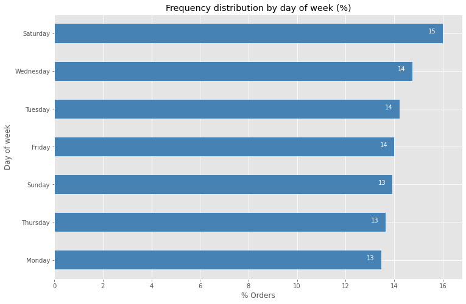

```
time: 2.12 s
```

```python
## Distribution %

orders_by_dayofweek = 100 * df['pickup_dayofweek'].value_counts() / len(df)

orders_by_dayofweek.sort_values(ascending=True, inplace=True)
orders_by_dayofweek.plot(kind='barh', figsize=(12, 8), color='steelblue')
plt.xlabel('% Orders')
plt.ylabel('Day of week')
plt.title('Frequency distribution by day of week (%)')

for i, value in enumerate(orders_by_dayofweek):
    label = format(int(value), ',') # format int with commas

    # place text at the end of bar (subtracting 0.8% from x, and 0 from y to make it fit within the bar)
    plt.annotate(label, xy=(value - 0.6, i - 0), color='white')

plt.show()
```

💡 **Highest demand on Saturday.** 💡 **Lowest demand on Monday.**  
*The pattern indicates a predominance of leisure demand, with some 'compensation feelings' when the workweek starts, for the extra spending on the weekend.*

### Tʀɪᴘs: Frequency distribution by pickup hour (%)

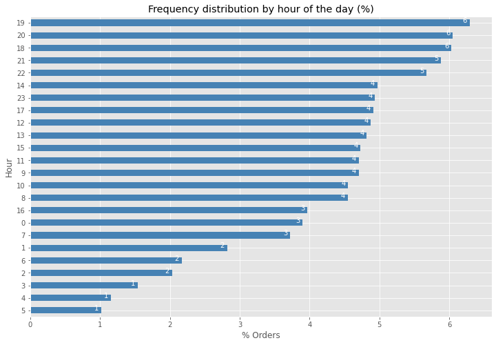

```
time: 1.92 s
```

```python
## Distribution %

orders_by_hour = 100 * df['pickup_hour'].value_counts() / len(df)

orders_by_hour.sort_values(ascending=True, inplace=True)
orders_by_hour.plot(kind='barh', figsize=(12, 8), color='steelblue')
plt.xlabel('% Orders')
plt.ylabel('Hour')
plt.title('Frequency distribution by hour of the day (%)')

for i, value in enumerate(orders_by_hour):
    label = format(int(value), ',') # format int with commas

    # place text at the end of bar (subtracting 0.8% from x, and 0 from y to make it fit within the bar)
    plt.annotate(label, xy=(value - 0.1, i - 0), color='white')

plt.show()
```

💡 **Highest demand from 18:00 to 23:00.** 💡 **Lowest demand from 01:00 to 07:00.**  
💡 **Preferred hours indicate that passengers are more inclined to go home** 🏡 **by taxi (rather than take taxi to get to work faster/rested, e.g.).**  
*With some aggregation, we can heve a clearer view. Let's create a new feature: time of the day.*

### Tʀɪᴘs: Frequency distribution by pickup time of the day (%)

```python
df.insert(loc=10, column='pickup_timeofday', value = df['pickup_hour'])
```

```
time: 390 ms
```

```python
timeofday_dict = {
               23: 'Night [20:00 to 01:00]',
               20: 'Evening [17:00 to 20:00]',
               17: 'Afternoon [12:00 to 17:00]',
               12: 'Morning [08:00 to 12:00]',
                8: 'Early morning [05:00 to 08:00]',
                5: 'Middle of the night [01:00 to 05:00]',
                1: 'Night [20:00 to 01:00]',
               }
```

```
time: 62 ms
```

```python
for i in range(len(timeofday_dict)):
    df.loc[df['pickup_hour'] <= int(list(timeofday_dict)[i]), 'pickup_timeofday'] = list(timeofday_dict.values())[i]
df.head(1)
```

|  | order_id | passenger_id | pickup_datetime | pickup_month | pickup_week | pickup_weekinmonth | pickup_date | pickup_dayofweek | pickup_isweekend | pickup_hour | pickup_timeofday | pickup_isrush | pickup_latitude | pickup_longitude | dropoff_latitude | dropoff_longitude | dropoff_datetime | duration | duration_minutes | duration_type | trip_distance | total_amount | fare_amount | tip_amount | rate_type | payment_type | pickup_borough | dropoff_borough | mph |
| --- | --- | --- | --- | --- | --- | --- | --- | --- | --- | --- | --- | --- | --- | --- | --- | --- | --- | --- | --- | --- | --- | --- | --- | --- | --- | --- | --- | --- | --- |
| 0 | 6433697 | 5234567816269547 | 2014-04-11 18:06:45 | 4 | 15 | 2 | 2014-04-11 | Friday | 0 | 18 | Evening [17:00 to 20:00] | 1 | 40.714476 | -74.015684 | 40.718173 | -74.000814 | 2014-04-11 18:18:19 | 0 days 00:11:34 | 11.566667 | 10-20min | 1.6 | 13.2 | 9.5 | 2.2 | Standard | CRD | Manhattan • Lower Manhattan | Manhattan • Lower Manhattan | 8.299712 |

```
time: 6min 41s
```

```python
df.count()
```

```
order_id              14999994
passenger_id          14999994
pickup_datetime       14999994
pickup_month          14999994
pickup_week           14999994
pickup_weekinmonth    14999994
pickup_date           14999994
pickup_dayofweek      14999994
pickup_isweekend      14999994
pickup_hour           14999994
pickup_timeofday      14999994
pickup_isrush         14999994
pickup_latitude       14726894
pickup_longitude      14726888
dropoff_latitude      11237187
dropoff_longitude     11237178
dropoff_datetime      11456221
duration              11456221
duration_minutes      11456221
duration_type         11456221
trip_distance         11456221
total_amount          11456221
fare_amount           11456221
tip_amount            11456221
rate_type             11456221
payment_type          14999994
pickup_borough        14999994
dropoff_borough       11456221
mph                   11381250
dtype: int64
```

```
time: 11 s
```

```python
orders_by_timeofday = 100 * df['pickup_timeofday'].value_counts() / len(df['pickup_timeofday'])
orders_by_timeofday
```

```
Afternoon [12:00 to 17:00]              23.400716
Night [20:00 to 01:00]                  23.212143
Morning [08:00 to 12:00]                18.839088
Evening [17:00 to 20:00]                18.370234
Early morning [05:00 to 08:00]          10.440578
Middle of the night [01:00 to 05:00]     5.737242
Name: pickup_timeofday, dtype: float64
```

```
time: 1.55 s
```

```python
sum(orders_by_timeofday)
```

```
100.0
```

```
time: 0 ns
```

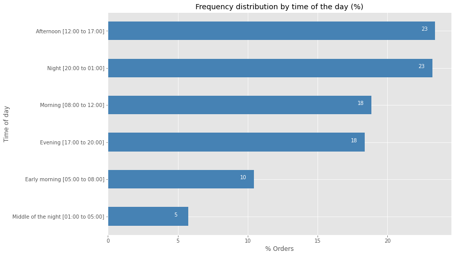

```
time: 3.19 s
```

```python
## Distribution %

orders_by_timeofday = 100 * df['pickup_timeofday'].value_counts() / len(df)

orders_by_timeofday.sort_values(ascending=True, inplace=True)
orders_by_timeofday.plot(kind='barh', figsize=(12, 8), color='steelblue')
plt.xlabel('% Orders')
plt.ylabel('Time of day')
plt.title('Frequency distribution by time of the day (%)')

for i, value in enumerate(orders_by_timeofday):
    label = format(int(value), ',') # format int with commas

    # place text at the end of bar (subtracting 0.8% from x, and 0 from y to make it fit within the bar)
    plt.annotate(label, xy=(value - 1, i - 0), color='white')

plt.show()
```

💡 **Highest demand on Afternoon [12:00 to 17:00].** 💡 **Lowest demand on Middle of the night [01:00 to 05:00].**  
*A better distribution can be seen by taking hourly data (normalizing for the different number of hours in each bin of time of the day).*

### Tʀɪᴘs: Frequency distribution by pickup time of the day (% hourly demand)

```python
orders_by_timeofday = 100 * df['pickup_timeofday'].value_counts() / len(df['pickup_timeofday'])
orders_by_timeofday
```

```
Afternoon [12:00 to 17:00]              23.400716
Night [20:00 to 01:00]                  23.212143
Morning [08:00 to 12:00]                18.839088
Evening [17:00 to 20:00]                18.370234
Early morning [05:00 to 08:00]          10.440578
Middle of the night [01:00 to 05:00]     5.737242
Name: pickup_timeofday, dtype: float64
```

```
time: 1.39 s
```

```python
#normalizing
orders_by_timeofday_nrm = orders_by_timeofday / [5,5,4,3,3,4]
orders_by_timeofday_nrm /= sum(orders_by_timeofday_nrm)
orders_by_timeofday_nrm *= 100
orders_by_timeofday_nrm.sort_values(ascending=False, inplace=True)
orders_by_timeofday_nrm
```

```
Evening [17:00 to 20:00]                24.425003
Morning [08:00 to 12:00]                18.786292
Afternoon [12:00 to 17:00]              18.668109
Night [20:00 to 01:00]                  18.517673
Early morning [05:00 to 08:00]          13.881758
Middle of the night [01:00 to 05:00]     5.721164
Name: pickup_timeofday, dtype: float64
```

```
time: 15 ms
```

```python
sum(orders_by_timeofday_nrm)
```

```
100.00000000000001
```

```
time: 0 ns
```

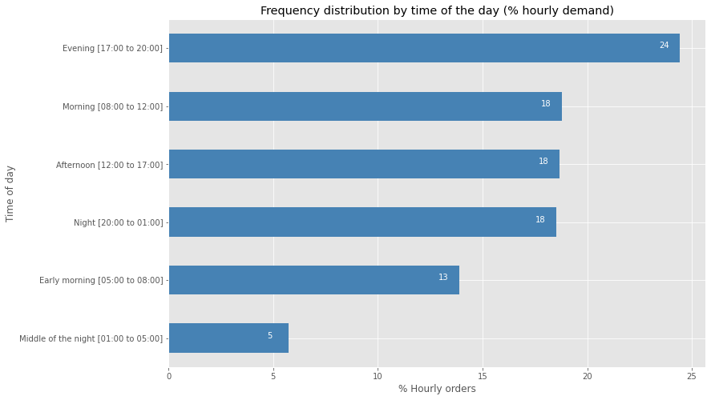

```
time: 297 ms
```

```python
## Distribution %

orders_by_timeofday_nrm.sort_values(ascending=True, inplace=True)
orders_by_timeofday_nrm.plot(kind='barh', figsize=(12, 8), color='steelblue')
plt.xlabel('% Hourly orders')
plt.ylabel('Time of day')
plt.title('Frequency distribution by time of the day (% hourly demand)')

for i, value in enumerate(orders_by_timeofday_nrm):
    label = format(int(value), ',') # format int with commas

    # place text at the end of bar (subtracting 1% from x, and 0 from y to make it fit within the bar)
    plt.annotate(label, xy=(value - 1, i - 0), color='white')

plt.show()
```

💡 **OPERATIONS:**  
🙂 *There is a nice baseline demand on Mornings, Nights, Afternoons.*  
⚡ *Peak demand occurs on Evenings.*  
✅ *Low demand takes place on Early mornings and in the MIddle of the night.*

### Tʀɪᴘs: Frequency distribution by trajectory duration (%)

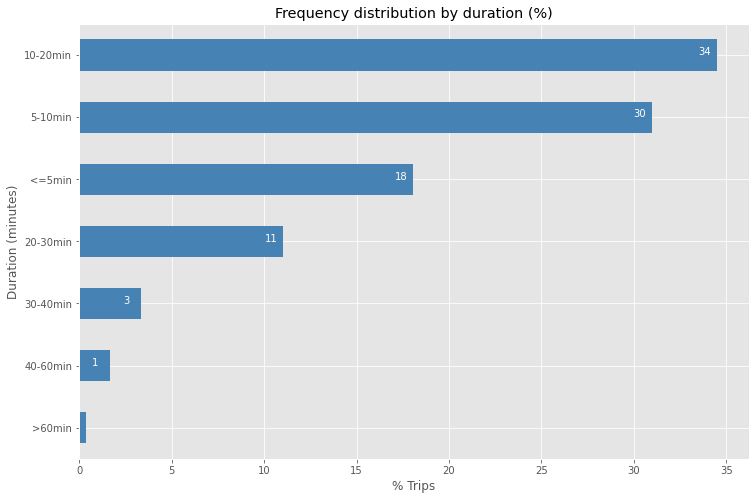

```
time: 3.39 s
```

```python
## Distribution %

orders_by_duration = 100 * df['duration_type'].value_counts() / (df['duration_type'].count())

orders_by_duration.sort_values(ascending=True, inplace=True)
orders_by_duration.plot(kind='barh', figsize=(12, 8), color='steelblue')
plt.xlabel('% Trips')
plt.ylabel('Duration (minutes)')
plt.title('Frequency distribution by duration (%)')

for i, value in enumerate(orders_by_duration):
    label = format(int(value), ',') # format int with commas

    # place text at the end of bar (subtracting 0.8% from x, and 0 from y to make it fit within the bar)
    plt.annotate(label, xy=(value - 1, i - 0), color='white')

plt.show()
```

💡 *82% of trips take 20 min or less*

### (Resuming after Kernel interruption)

```python
with open('df_orders_tF_EDA.csv') as f: cols = f.readline().split(',')
del cols[0]
cols[-1] = cols[-1].replace('\n','')
df_original = pd.read_csv('df_orders_tF_EDA.csv', usecols=cols) # reading previously transformed data (EDA_v9)
df = pd.read_csv('df_orders_tF_EDA.csv', usecols=cols) # reading previously transformed data (EDA_v9)
df.head(2)
```

|  | order_id | passenger_id | pickup_datetime | pickup_month | pickup_week | pickup_weekinmonth | pickup_date | pickup_dayofweek | pickup_isweekend | pickup_hour | pickup_timeofday | pickup_isrush | pickup_latitude | pickup_longitude | dropoff_latitude | dropoff_longitude | dropoff_datetime | duration | duration_minutes | duration_type | trip_distance | total_amount | fare_amount | tip_amount | rate_type | payment_type | pickup_borough | dropoff_borough | mph |
| --- | --- | --- | --- | --- | --- | --- | --- | --- | --- | --- | --- | --- | --- | --- | --- | --- | --- | --- | --- | --- | --- | --- | --- | --- | --- | --- | --- | --- | --- |
| 0 | 6433697 | 5234567816269547 | 2014-04-11 18:06:45 | 4 | 15 | 2 | 2014-04-11 | Friday | 0 | 18 | Evening [17:00 to 20:00] | 1 | 40.714476 | -74.015684 | 40.718173 | -74.000814 | 2014-04-11 18:18:19 | 0 days 00:11:34 | 11.566667 | 10-20min | 1.6 | 13.2 | 9.5 | 2.2 | Standard | CRD | Manhattan • Lower Manhattan | Manhattan • Lower Manhattan | 8.299712 |
| 1 | 6433698 | 5234567812367422 | 2014-04-12 00:20:28 | 4 | 15 | 2 | 2014-04-12 | Saturday | 1 | 0 | Night [20:00 to 01:00] | 0 | 40.713247 | -73.958403 | 40.758526 | -73.991395 | 2014-04-12 00:47:19 | 0 days 00:26:51 | 26.850000 | 20-30min | 5.5 | 27.0 | 22.0 | 4.0 | Standard | CRD | Brooklyn | Manhattan • Midtown Manhattan | 12.290503 |

```
time: 10min 53s
```

```python
%matplotlib inline

import matplotlib as mpl
import matplotlib.pyplot as plt

mpl.style.use('ggplot')
```

```
time: 0 ns
```

### Tʀɪᴘs: Frequency distribution by trajectory length (%)

```python
df['trip_distance'].describe()
```

```
count    1.145622e+07
mean     2.903006e+00
std      3.423146e+00
min      0.000000e+00
25%      1.020000e+00
50%      1.770000e+00
75%      3.200000e+00
max      1.089000e+02
Name: trip_distance, dtype: float64
```

```
time: 1.14 s
```

```python
print(df['trip_distance'].describe()[7])
print(df['trip_distance'].describe()[6])
print(df['trip_distance'].describe()[5])
print(df['trip_distance'].describe()[4])
```

```
108.9
3.2
1.77
1.02
time: 3.52 s
```

```python
orders_by_distance_dict = {'far (more than 10 miles)':              100 * sum( (df['trip_distance'] <= 108.9) & (df['trip_distance'] > 10) ) / df['trip_distance'].count()}
orders_by_distance_dict['moderately distant (more than 5 miles)'] = 100 * sum( (df['trip_distance'] <= 10)    & (df['trip_distance'] >  5) ) / df['trip_distance'].count()
orders_by_distance_dict['close (1 to 5 miles)']                   = 100 * sum( (df['trip_distance'] <= 5)     & (df['trip_distance'] >  1) ) / df['trip_distance'].count()
orders_by_distance_dict['very close (less than 1 mile)']          = 100 * sum( (df['trip_distance'] <= 1)                                  ) / df['trip_distance'].count()
orders_by_distance_dict
```

```
{'far (more than 10 miles)': 4.901302096040221,
 'moderately distant (more than 5 miles)': 8.76107400511914,
 'close (1 to 5 miles)': 61.755241977262834,
 'very close (less than 1 mile)': 24.582381921577806}
```

```
time: 8.86 s
```

```python
sum(orders_by_distance_dict.values())
```

```
100.0
```

```
time: 0 ns
```

```python
orders_by_distance = pd.DataFrame(
                      orders_by_distance_dict.values(),
              index = orders_by_distance_dict.keys(),
              columns = ['%'])
orders_by_distance.sort_values(by='%',ascending=False, inplace=True)
orders_by_distance
```

|  | % |
| --- | --- |
| close (1 to 5 miles) | 61.755242 |
| very close (less than 1 mile) | 24.582382 |
| moderately distant (more than 5 miles) | 8.761074 |
| far (more than 10 miles) | 4.901302 |

```
time: 0 ns
```

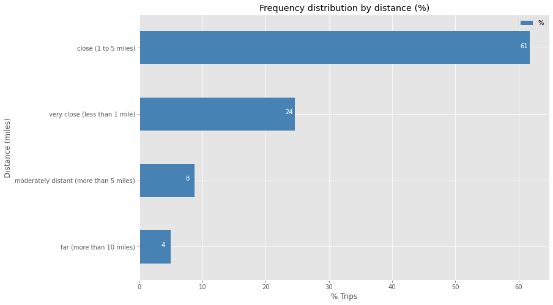

```
time: 391 ms
```

```python
## Distribution %

orders_by_distance.sort_values(by='%',ascending=True, inplace=True)
orders_by_distance.plot(kind='barh', figsize=(12, 8), color='steelblue')
plt.xlabel('% Trips')
plt.ylabel('Distance (miles)')
plt.title('Frequency distribution by distance (%)')

for i, value in enumerate(orders_by_distance['%']):
    label = format(int(value), ',') # format int with commas

    # place text at the end of bar (subtracting 1% from x, and 0 from y to make it fit within the bar)
    plt.annotate(label, xy=(value - 1.5, i - 0), color='white')

plt.show()
```

### Tʀɪᴘs: Frequency distribution by pickup borough (%)

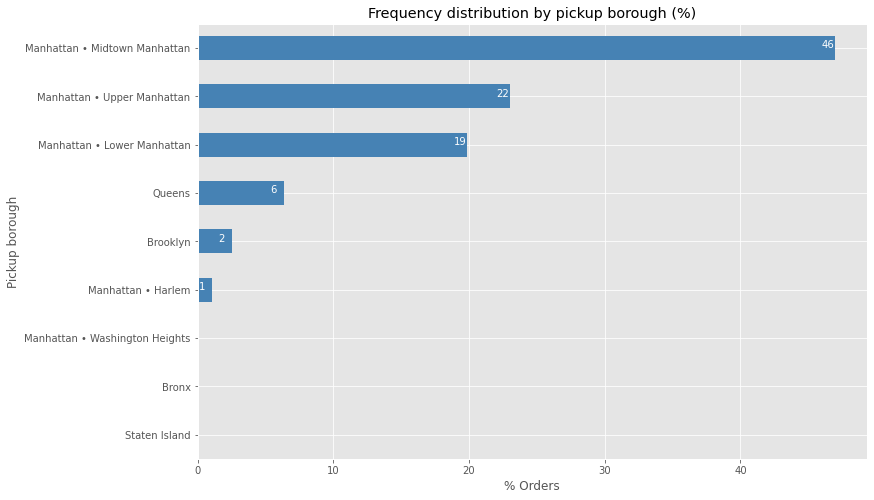

```
time: 4.45 s
```

```python
## Distribution %

orders_by_pickup_borough = 100 * df['pickup_borough'].value_counts() / (df['pickup_borough'].count())

orders_by_pickup_borough.sort_values(ascending=True, inplace=True)
orders_by_pickup_borough.plot(kind='barh', figsize=(12, 8), color='steelblue')
plt.xlabel('% Orders')
plt.ylabel('Pickup borough')
plt.title('Frequency distribution by pickup borough (%)')

for i, value in enumerate(orders_by_pickup_borough):
    label = format(int(value), ',') # format int with commas

    # place text at the end of bar (subtracting 1% from x, and 0 from y to make it fit within the bar)
    plt.annotate(label, xy=(value - 1, i - 0), color='white')

plt.show()
```

### Tʀɪᴘs: Frequency distribution by dropoff borough (%)

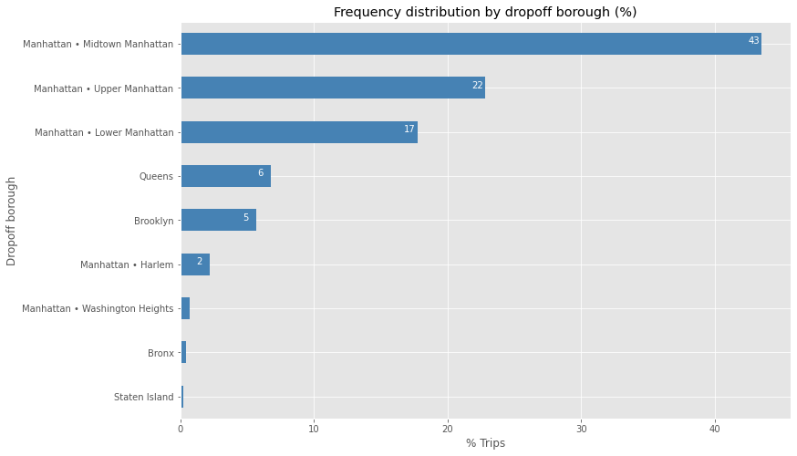

```
time: 3.23 s
```

```python
## Distribution %

orders_by_dropoff_borough = 100 * df['dropoff_borough'].value_counts() / (df['dropoff_borough'].count())

orders_by_dropoff_borough.sort_values(ascending=True, inplace=True)
orders_by_dropoff_borough.plot(kind='barh', figsize=(12, 8), color='steelblue')
plt.xlabel('% Trips')
plt.ylabel('Dropoff borough')
plt.title('Frequency distribution by dropoff borough (%)')

for i, value in enumerate(orders_by_dropoff_borough):
    label = format(int(value), ',') # format int with commas

    # place text at the end of bar (subtracting 1% from x, and 0 from y to make it fit within the bar)
    plt.annotate(label, xy=(value - 1, i - 0), color='white')

plt.show()
```

💡 **Meeting the inference we got for the chart of distribution for pickup hour, the pattern with pickup/dropoff boroughs indicates that passengers are more inclined to go home** 🏡 **by taxi (rather than take taxi to get to work faster/rested, e.g.).**

### Tʀɪᴘs: Frequency distribution by rate type (%)

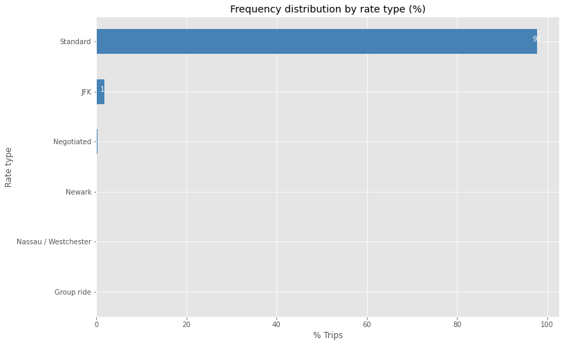

```
time: 2.88 s
```

```python
## Distribution %

orders_by_rate_type = 100 * df['rate_type'].value_counts() / (df['rate_type'].count())

orders_by_rate_type.sort_values(ascending=True, inplace=True)
orders_by_rate_type.plot(kind='barh', figsize=(12, 8), color='steelblue')
plt.xlabel('% Trips')
plt.ylabel('Rate type')
plt.title('Frequency distribution by rate type (%)')

for i, value in enumerate(orders_by_rate_type):
    label = format(int(value), ',') # format int with commas

    # place text at the end of bar (subtracting 0.8% from x, and 0 from y to make it fit within the bar)
    plt.annotate(label, xy=(value - 1, i - 0), color='white')

plt.show()
```

💡 **Non-standard rate represents an ultra-tiny fraction of the business.** 💡 **Exception for the 1% of JFK.**